# HW1

Eda Kocakarin - IE360 - Fall 2020

11/11/2020

# Data Visualization and Google Trends on Three Different Measures from Turkey

# 1) Monthly 2nd Hand Online Automative Market of Turkey over 2018-2020

First of all, there are monthly data of second hand online automative markets that taken from OOD’s (Otomativ Distribütörleri Derneği) website. Below you can find the histograms of these data from 2018 to 2020, categorized by years.

## Histograms of 2nd Hand Online Automative Market from 2018 to 2020

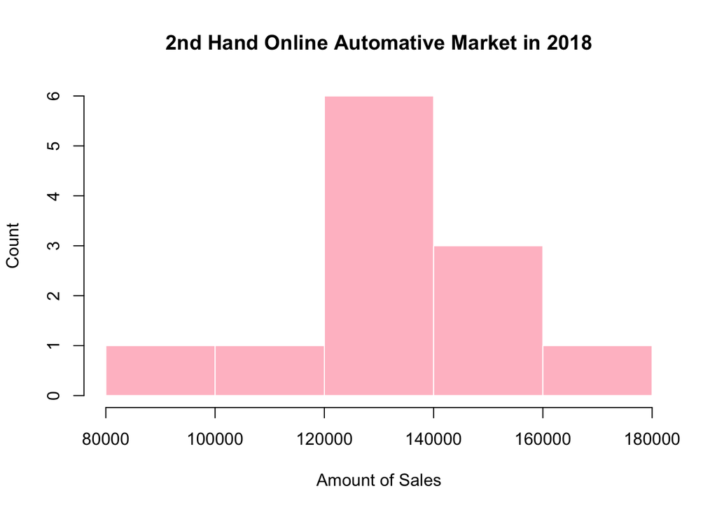

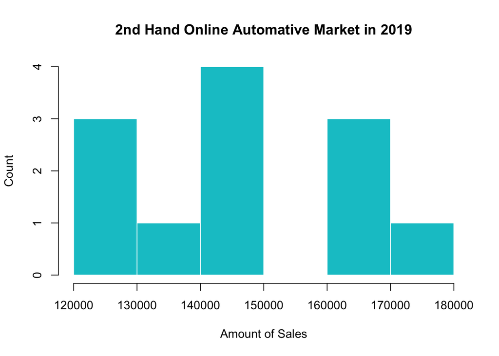

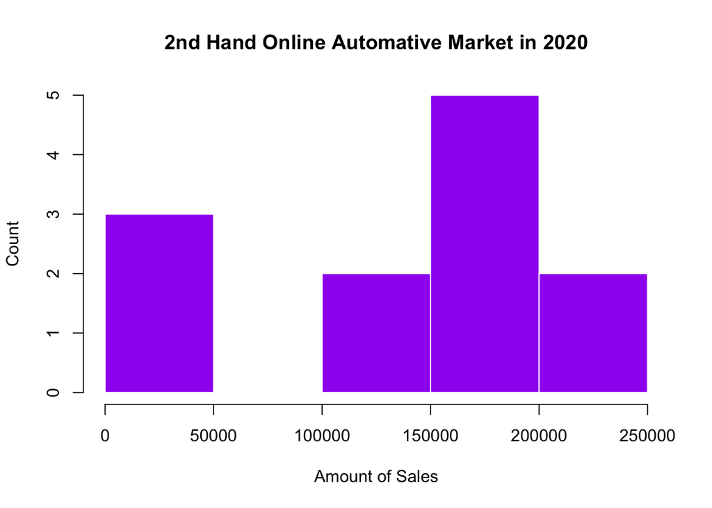

## Boxplots of Search Analysis of ‘İkinci El Araba’ in Google Search vs. 2nd Hand Online Automative Market in 2018

Since the short time interval data taken from Google Trends is weekly and I have categorized the search data by months in order to compare them with the monthly data I received from the OOD’s website.

I predicted that there was a relationship between second hand online car sales data and the ‘ikinci el araba’ searches I took from google trends. For this reason, I had the boxplots drawn by months and compared them.

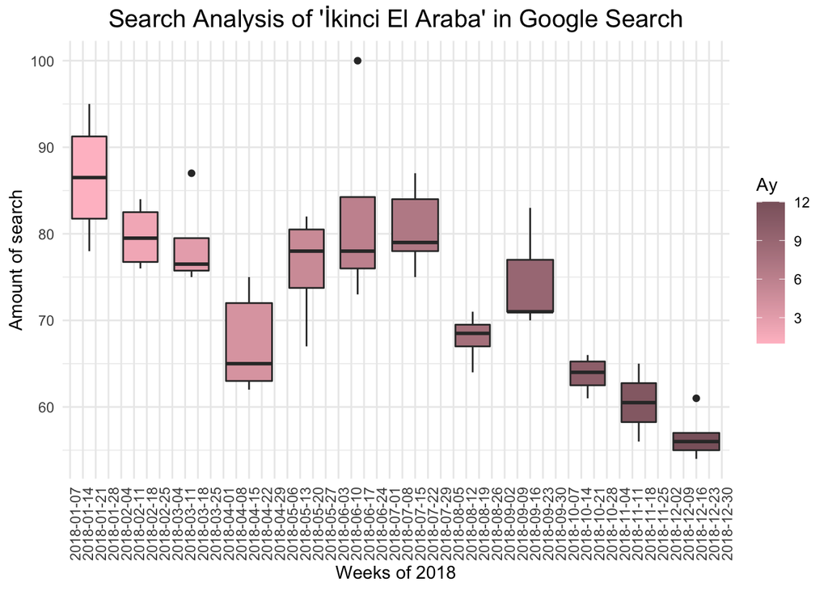

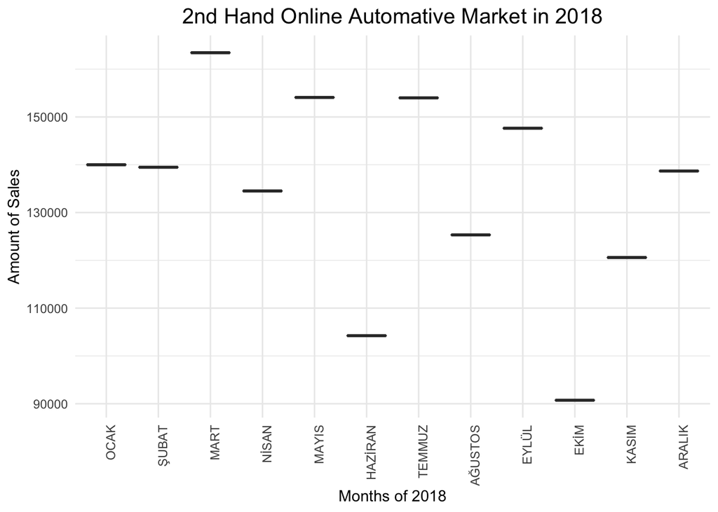

## Boxplots of Search Analysis of ‘İkinci El Araba’ in Google Search vs. 2nd Hand Online Automative Market in 2019

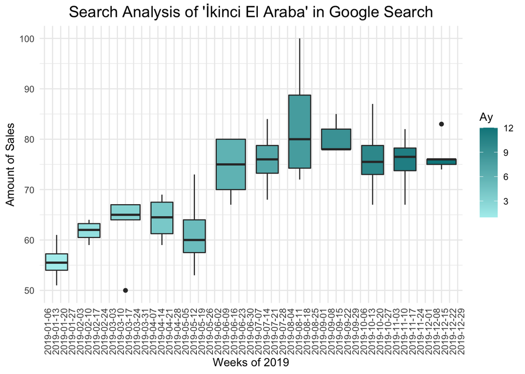

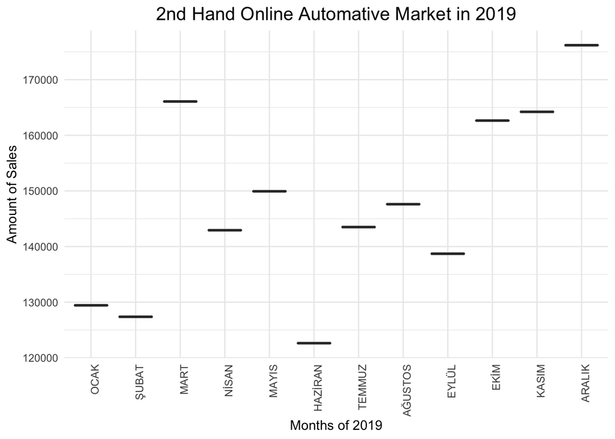

## Boxplots of Search Analysis of ‘İkinci El Araba’ in Google Search vs. 2nd Hand Online Automative Market in 2020

Here are the boxplots of 2020 for search analysis of ‘ikinci el araba’ and also second hand car sales.

The coronavirus disease, which started in our country as of the first quarter of 2020, has caused a serious production halt worldwide. Due to this stagnation in the zero car market, people turned to second hand cars.

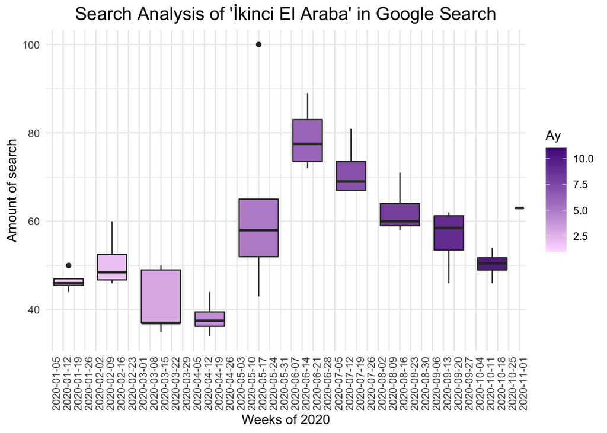

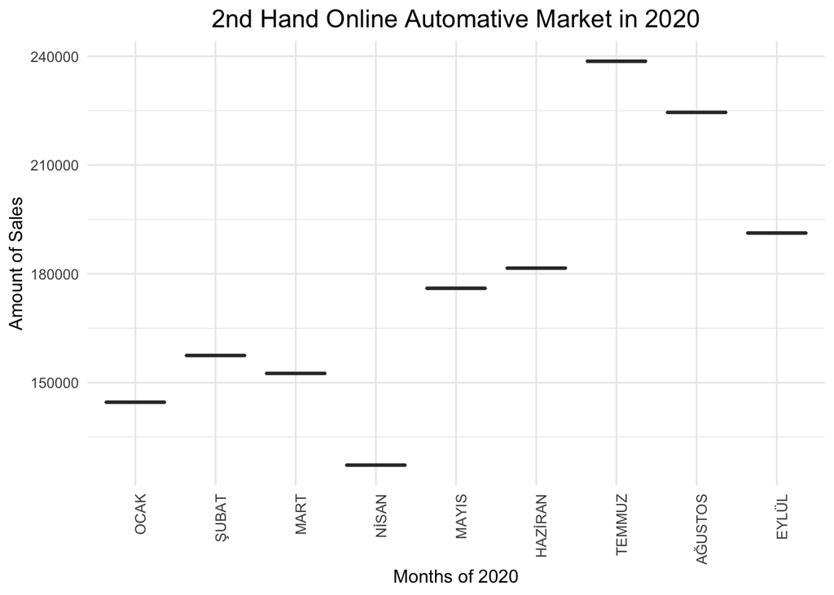

# 2) Monthly Dollar Exchange Rate in Turkey over 2012-2019

## A Histogram of Dollar Exchange Rate from 2012 to 2019

In this study, I wanted to observe the change in the dollar exchange rate with time. Dollar exchange rate from 2012 to 2019 has generally increased. This is the histogram of dollar exchange rate from 2012 to 2019.

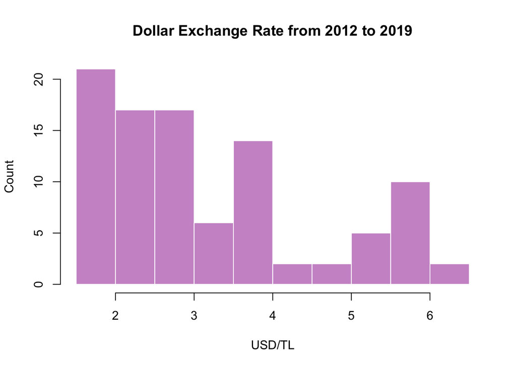

## Boxplots of Search Analysis of ‘Dolar Kaç’ in Google Search vs. Dollar Exchange Rate in Turkey from 2012 to 2019

I thought there might be a relationship between the increase in the dollar rate over time and ‘dolar kaç’ google searches. I visualized these in order to understand that people who are investing, willing, or interested in the economy, search for ‘dolar kaç’ during the day parallels the increase in dollar.

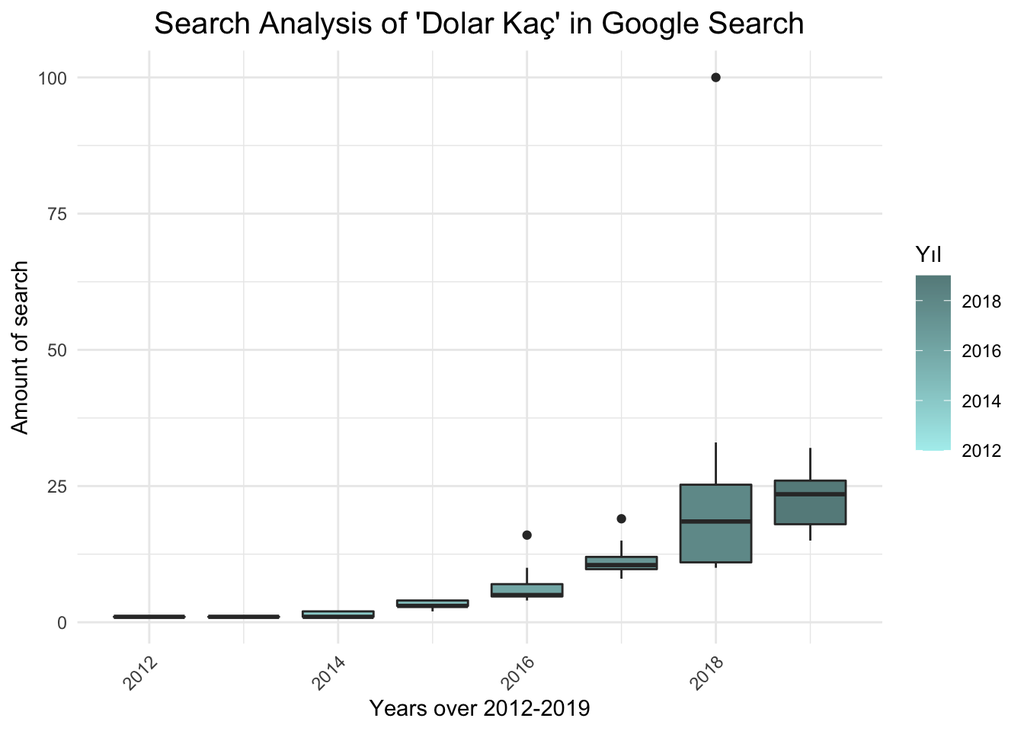

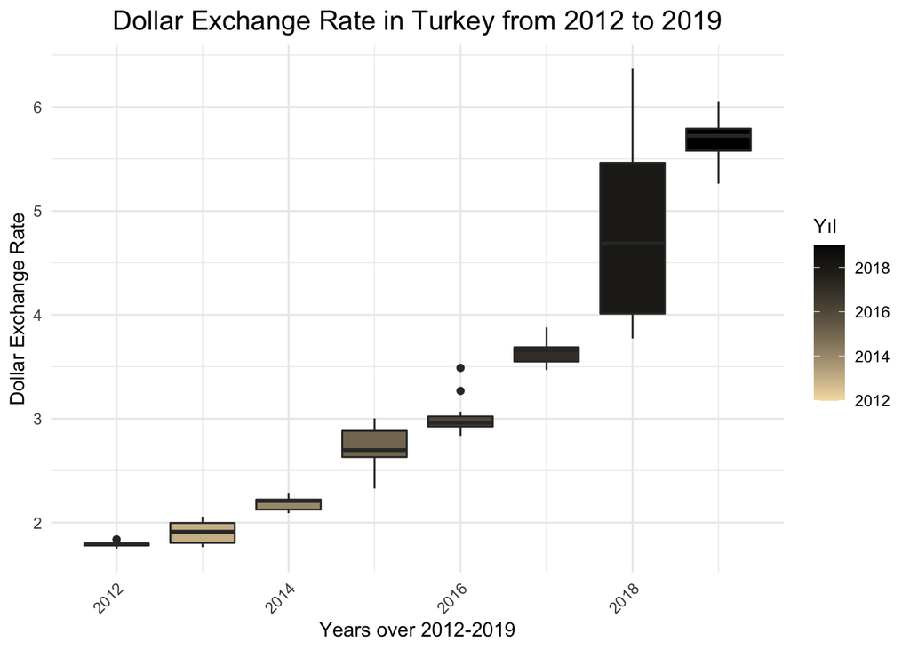

I categorized the two different datasets by year, withdrawing the search data between 2012 and 2019 from Google Trends and the dollar rate from the required places monthly. I chose to draw the boxplots by year to facilitate the comparison and make the monthly data more understandable.

With the dollar rate that has been increasing since 2012, the ‘dolar kaç’ search data from google trends, which has been continuously increasing since 2012, is in parallel.

# 3) Monthly Average Cigarette Price in Turkey from 2013-01 to 2020-06

The price of cigarettes sold in Turkey has been increasing for a long time. For this reason, I collected data to investigate the increasing cigarette prices I was curious about and to reveal its relationship with the searches for ‘sigara vergisi’ & ‘özel tüketim vergisi’.

## A Histogram of Average Cigarette Price in Turkey from 2013-01 to 2020-06

Below you can find the histogram graph of the monthly average cigarette sales prices I found from January 2013 to June 2020.

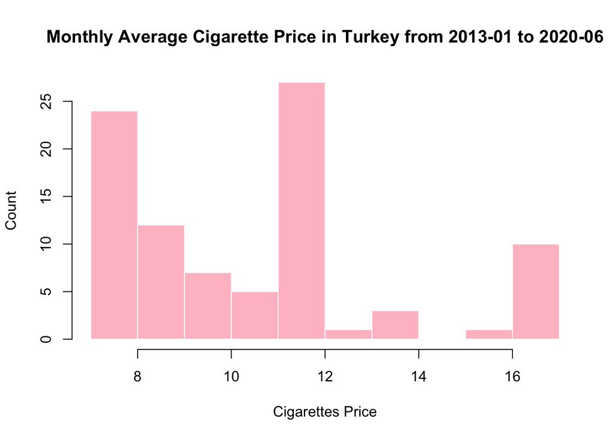

## Boxplots of Search Analysis of ‘sigara vergisi’ & ‘özel tüketim vergisi’ in Google Search vs. Monthly Average Cigarette Price in Turkey from 2013-01 to 2020-06

The data I used was monthly from 2013-01 to 2020-06. Instead of plotting all of them monthly, I converted the monthly data into annual data cumulatively.

Below you can find boxplots of google trends ‘sigara vergisi’ & ‘özel tüketim vergisi’ datas and cigarette prices taken from 2013-01 to 2020-06.

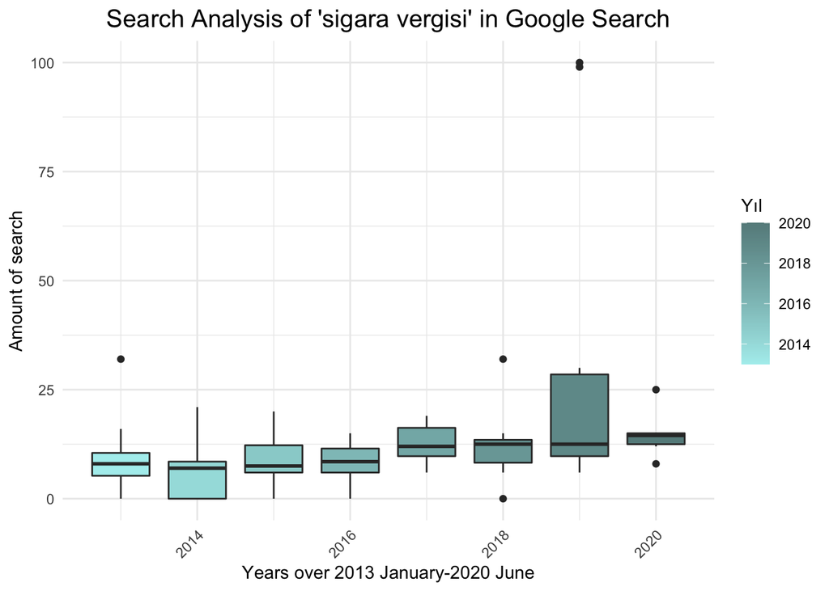

[figure not shown]

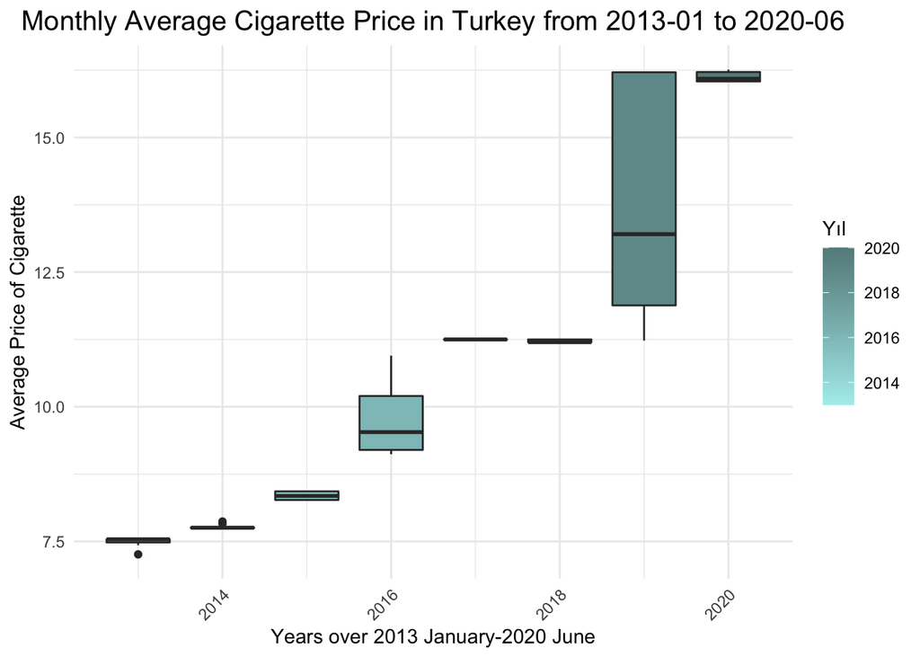

#### References

[Google Trends](https://trends.google.com/trends/?geo=US)/ [Otomotiv Distribütörleri Derneği](http://www.odd.org.tr/web_2837_1/neuralnetwork.aspx?type=35)/ [Sigara Fiyatları Veri Kaynağı](https://www.verikaynagi.com)/ [Türkiye Cumhuriyet Merkez Bankası](https://evds2.tcmb.gov.tr)

#### Related Codes used for Homework1

[Codes](https://github.com/BU-IE-360/fall20-edakocakarin/blob/gh-pages/files/HW1.Rmd)